# Prediction Assignment Writeup

Goran

Monday, February 22, 2016

## Background

Using devices such as Jawbone Up, Nike FuelBand, and Fitbit it is now possible to collect a large amount of data about personal activity relatively inexpensively. These type of devices are part of the quantified self movement – a group of enthusiasts who take measurements about themselves regularly to improve their health, to find patterns in their behavior, or because they are tech geeks. One thing that people regularly do is quantify how much of a particular activity they do, but they rarely quantify how well they do it. In this project, your goal will be to use data from accelerometers on the belt, forearm, arm, and dumbell of 6 participants. They were asked to perform barbell lifts correctly and incorrectly in 5 different ways:

- exactly according to the specification (Class A)
- throwing the elbows to the front (Class B)
- lifting the dumbbell only halfway (Class C)
- lowering the dumbbell only halfway (Class D)
- throwing the hips to the front (Class E).

More information is available from the website here: http://groupware.les.inf.puc-rio.br/har (see the section on the Weight Lifting Exercise Dataset).

## Data

The training data for this project are available here: https://d396qusza40orc.cloudfront.net/predmachlearn/pml-training.csv

The test data are available here: https://d396qusza40orc.cloudfront.net/predmachlearn/pml-testing.csv

The data for this project come from this source: http://groupware.les.inf.puc-rio.br/har.

## Getting Data

Load the CSV files into R-studio. Mark missing values as NA.

```r
trainingData  <- read.csv("pml-training.csv", na.strings=c("NA","#DIV/0!",""))
testingData <- read.csv("pml-testing.csv", na.strings=c("NA","#DIV/0!",""))
```

## Explore Data

We see that the training dataset contains 19622 observations of 160 variables. We need to narrow or data set, to be able to build a good model. The first 7 columns are unrelated and can be removed from the dataset.

```r
# loading libraries
library(AppliedPredictiveModeling)
library(ggplot2)
library(lattice)
library(caret)
library(corrplot)
library(randomForest)
library(e1071)

# setting the overall seed for reproduceability
set.seed(4711)
```

```r
dim(trainingData)
```

```
## [1] 19622   160
```

```r
dim(testingData)
```

```
## [1]  20 160
```

```r
str(trainingData$classe)
```

```
##  Factor w/ 5 levels "A","B","C","D",..: 1 1 1 1 1 1 1 1 1 1 ...
```

```r
names(trainingData)
```

```
##   [1] "X"                        "user_name"
##   [3] "raw_timestamp_part_1"     "raw_timestamp_part_2"
##   [5] "cvtd_timestamp"           "new_window"
##   [7] "num_window"               "roll_belt"
##   [9] "pitch_belt"               "yaw_belt"
##  [11] "total_accel_belt"         "kurtosis_roll_belt"
##  [13] "kurtosis_picth_belt"      "kurtosis_yaw_belt"
##  [15] "skewness_roll_belt"       "skewness_roll_belt.1"
##  [17] "skewness_yaw_belt"        "max_roll_belt"
##  [19] "max_picth_belt"           "max_yaw_belt"
##  [21] "min_roll_belt"            "min_pitch_belt"
##  [23] "min_yaw_belt"             "amplitude_roll_belt"
##  [25] "amplitude_pitch_belt"     "amplitude_yaw_belt"
##  [27] "var_total_accel_belt"     "avg_roll_belt"
##  [29] "stddev_roll_belt"         "var_roll_belt"
```

[output cut: 65 more lines]

```r
summary(trainingData)[,1:10]
```

```
##        X              user_name      raw_timestamp_part_1
##  "Min.   :    1  " "adelmo  :3892  " "Min.   :1.322e+09  "
##  "1st Qu.: 4906  " "carlitos:3112  " "1st Qu.:1.323e+09  "
##  "Median : 9812  " "charles :3536  " "Median :1.323e+09  "
##  "Mean   : 9812  " "eurico  :3070  " "Mean   :1.323e+09  "
##  "3rd Qu.:14717  " "jeremy  :3402  " "3rd Qu.:1.323e+09  "
##  "Max.   :19622  " "pedro   :2610  " "Max.   :1.323e+09  "
##  NA                NA                NA
##  raw_timestamp_part_2          cvtd_timestamp    new_window
##  "Min.   :   294  "   "28/11/2011 14:14: 1498  " "no :19216  "
##  "1st Qu.:252912  "   "05/12/2011 11:24: 1497  " "yes:  406  "
##  "Median :496380  "   "30/11/2011 17:11: 1440  " NA
##  "Mean   :500656  "   "05/12/2011 11:25: 1425  " NA
##  "3rd Qu.:751891  "   "02/12/2011 14:57: 1380  " NA
##  "Max.   :998801  "   "02/12/2011 13:34: 1375  " NA
##  NA                   "(Other)         :11007  " NA
##    num_window        roll_belt          pitch_belt
##  "Min.   :  1.0  " "Min.   :-28.90  " "Min.   :-55.8000  "
##  "1st Qu.:222.0  " "1st Qu.:  1.10  " "1st Qu.:  1.7600  "
##  "Median :424.0  " "Median :113.00  " "Median :  5.2800  "
##  "Mean   :430.6  " "Mean   : 64.41  " "Mean   :  0.3053  "
##  "3rd Qu.:644.0  " "3rd Qu.:123.00  " "3rd Qu.: 14.9000  "
##  "Max.   :864.0  " "Max.   :162.00  " "Max.   : 60.3000  "
##  NA                NA                 NA
##     yaw_belt
##  "Min.   :-180.00  "
##  "1st Qu.: -88.30  "
##  "Median : -13.00  "
##  "Mean   : -11.21  "
##  "3rd Qu.:  12.90  "
##  "Max.   : 179.00  "
##  NA
```

```r
# Remove the first 7 columns
trainingData <- trainingData[,-seq(1:7)]
testingData <- testingData[,-seq(1:7)]
```

## Cleaning Data

There are several columns with missing values, we will remove them. After removing the missing values we have 53 variables.

```r
indexNA <- as.vector(sapply(trainingData[,1:152],function(x) {length(which(is.na(x)))!=0}))
training <- trainingData[,!indexNA]
testing <- testingData[,!indexNA]
dim(training)
```

```
## [1] 19622    53
```

Remove correlated variables.

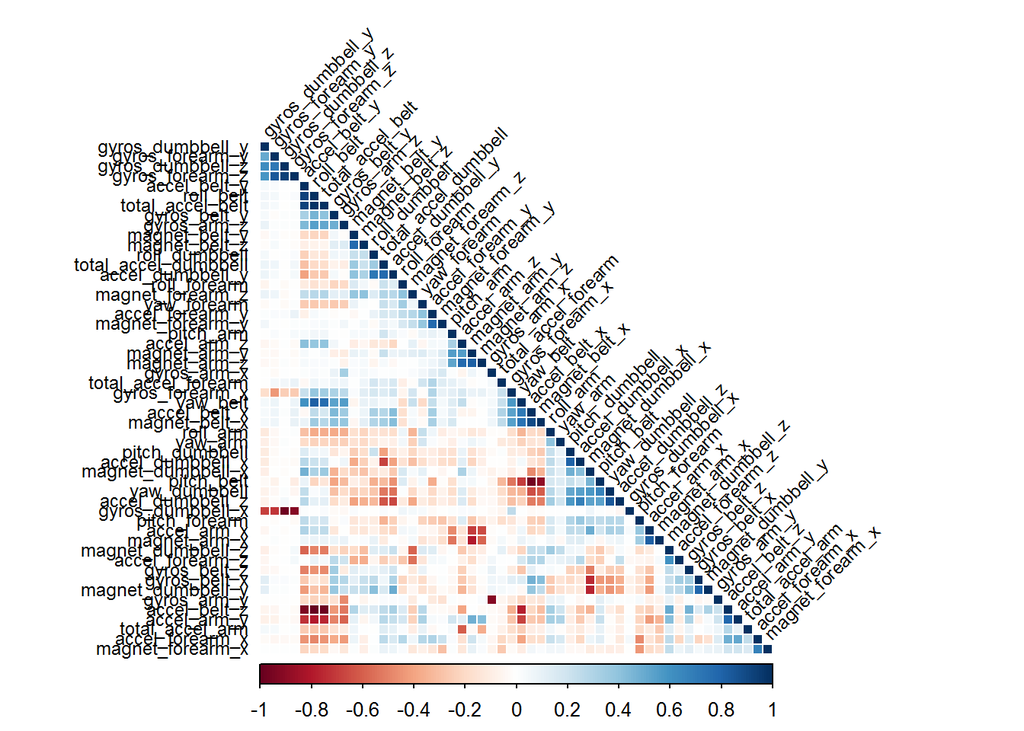

```r
corMatrix <- cor(training[,-dim(training)[2]],)
corrplot(corMatrix, method = "color", type="lower", order="hclust", tl.cex = 0.75, tl.col="black", tl.srt = 45)
```

```r
# Find variables with high correlation, and remove them
correlation <- findCorrelation(corMatrix, cutoff = 0.5)
training <- training[,-correlation]
dim(training)
```

```
## [1] 19622    22
```

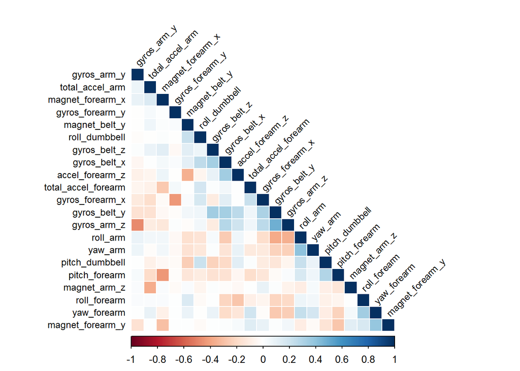

```r
corMatrix <- cor(training[,-dim(training)[2]],)
corrplot(corMatrix, method = "color", type="lower", order="hclust", tl.cex = 0.75, tl.col="black", tl.srt = 45)
```

```r
# Do the same for the testing
testing <- testing[,-correlation]
dim(testing)
```

```
## [1] 20 22
```

## Building the prediction model

Create cross validation dataset

```r
# Partition data set between training and validation, for cross validation.
inTrain <- createDataPartition(training$classe, p=0.7, list=FALSE)
trainingPart <- training[inTrain, ]
validationPart <- training[-inTrain, ]

dim(trainingPart)
```

```
## [1] 13737    22
```

```r
dim(validationPart)
```

```
## [1] 5885   22
```

## Training prediction results

The machine learning model is trained using a random forest. We build a model using the training set.

```r
modelFit <- train(classe ~., method = "rf", data=trainingPart, trControl=trainControl(method="cv"), importance=TRUE)
print(modelFit)
```

```
## Random Forest
##
## 13737 samples
##    21 predictor
##     5 classes: 'A', 'B', 'C', 'D', 'E'
##
## No pre-processing
## Resampling: Cross-Validated (10 fold)
## Summary of sample sizes: 12362, 12363, 12364, 12364, 12365, 12364, ...
## Resampling results across tuning parameters:
##
##   mtry  Accuracy   Kappa      Accuracy SD  Kappa SD
##    2    0.9793271  0.9738416  0.002803234  0.003550544
##   11    0.9726302  0.9653694  0.005395556  0.006831422
##   21    0.9632404  0.9534906  0.006839100  0.008654847
##
## Accuracy was used to select the optimal model using  the largest value.
## The final value used for the model was mtry = 2.
```

## Cross Validation Testing

Test model on training dataset

```r
# results with training dataset
predictTrain <- predict(modelFit, trainingPart)
confusionMatrix(predictTrain,trainingPart$classe)
```

```
## Confusion Matrix and Statistics
##
##           Reference
## Prediction    A    B    C    D    E
##          A 3906    0    0    0    0
##          B    0 2658    0    0    0
##          C    0    0 2396    0    0
##          D    0    0    0 2252    0
##          E    0    0    0    0 2525
##
## Overall Statistics
##
##                Accuracy : 1
##                  95% CI : (0.9997, 1)
##     No Information Rate : 0.2843
##     P-Value [Acc > NIR] : < 2.2e-16
##
##                   Kappa : 1
##  Mcnemar's Test P-Value : NA
##
## Statistics by Class:
##
##                      Class: A Class: B Class: C Class: D Class: E
## Sensitivity            1.0000   1.0000   1.0000   1.0000   1.0000
## Specificity            1.0000   1.0000   1.0000   1.0000   1.0000
## Pos Pred Value         1.0000   1.0000   1.0000   1.0000   1.0000
## Neg Pred Value         1.0000   1.0000   1.0000   1.0000   1.0000
## Prevalence             0.2843   0.1935   0.1744   0.1639   0.1838
## Detection Rate         0.2843   0.1935   0.1744   0.1639   0.1838
## Detection Prevalence   0.2843   0.1935   0.1744   0.1639   0.1838
## Balanced Accuracy      1.0000   1.0000   1.0000   1.0000   1.0000
```

Test model on validation dataset. The accuracy shows the expected out of sample error expected. Accuracy: 0.98 gives the xpected out-of-sample error: 0.02

```r
# results with validation dataset
predictValid <- predict(modelFit,validationPart)
confMatrix <- confusionMatrix(predictValid, validationPart$classe)
confMatrix
```

```
## Confusion Matrix and Statistics
##
##           Reference
## Prediction    A    B    C    D    E
##          A 1664   13    0    1    0
##          B    5 1117   15    2    2
##          C    2    8 1003   30    2
##          D    3    0    8  925    3
##          E    0    1    0    6 1075
##
## Overall Statistics
##
##                Accuracy : 0.9828
##                  95% CI : (0.9792, 0.986)
##     No Information Rate : 0.2845
##     P-Value [Acc > NIR] : < 2.2e-16
##
##                   Kappa : 0.9783
##  Mcnemar's Test P-Value : NA
##
## Statistics by Class:
##
##                      Class: A Class: B Class: C Class: D Class: E
## Sensitivity            0.9940   0.9807   0.9776   0.9595   0.9935
## Specificity            0.9967   0.9949   0.9914   0.9972   0.9985
## Pos Pred Value         0.9917   0.9790   0.9598   0.9851   0.9935
## Neg Pred Value         0.9976   0.9954   0.9952   0.9921   0.9985
## Prevalence             0.2845   0.1935   0.1743   0.1638   0.1839
## Detection Rate         0.2828   0.1898   0.1704   0.1572   0.1827
## Detection Prevalence   0.2851   0.1939   0.1776   0.1596   0.1839
## Balanced Accuracy      0.9954   0.9878   0.9845   0.9783   0.9960
```

## Test Prediction Results

Predicting Performance on Testing Dataset.

```r
# apply the model that we have to our test set, do we need to refine?
predictTest <- predict(modelFit, newdata=testing)
predictTest
```

```
##  [1] B A B A A E D B A A B C B A E E A B B B
## Levels: A B C D E
```

## Summary

In this report we have showed how a prediction model is built using machine learning. We have used the Random Forrest algorithm to build train our model. We have used a patition of the traningset for cross validation. The expected out of sample error did show the correct classified observation in the cross-validation dataset. Finally we have predicted the 20 different test cases with our prediction model.